# School belonging data analysis, short IDA

- Show All Code
- Hide All Code
- View Source

Author

Michael Kammer

Published

2025-06-30

# 1 Background

This frequentist analysis for the school belonging analysis task follows the statistical analysis plan by Michael Kammer dated 30.6.2025 (and referring to the task description for the simplified school belonging task with the same date that addresses a binary outcome variable). Here we present a very short initial data analysis common to the Frequentist and Bayesian workflows.

# 2 Setup and data

- ATT4 is computed by the `ggplot2::cut_number()` function, as outlined by Mariana in her SAP.
- bel01 is computed as the lowest 25% of students in terms of sense of belonging in `belong`.

```r
T_START = Sys.time()
SUFFIX = ""

# data handling and printing
library(tidyverse)
library(glue)
library(magrittr)
library(patchwork)
library(gtsummary)
library(gt)

# plotting
library(GGally)

rm(list = c("pisa2018"))
load("Data/Raw/pisa2018.Rdata")

pisa2018 %<>% mutate(
        ATT4 = cut_number(ATT01, 4),
        bel01 = belong <= quantile(belong, probs = 0.25, na.rm = TRUE)
    )
```

## 2.1 Helper functions

Code for helper functions.

```r
plot_density_and_box <- function(plotdf, v) {
    list(
        ggplot(plotdf, aes(x = .data[[v]])) +
            geom_density() +
            theme_bw() +
            theme(axis.title.x = element_blank(),
                  axis.text.x = element_blank(),
                  axis.ticks.x = element_blank(),
                  plot.margin = margin()),
        ggplot(plotdf, aes(x = .data[[v]], y = 0)) +
            geom_boxplot(outlier.shape = NA) +
            geom_jitter(height = 0.25, width = 0, alpha = 0.1) +
            theme_bw() +
            theme(axis.text.y = element_blank(),
                  axis.title.y = element_blank(),
                  axis.ticks.y = element_blank(),
                  panel.grid.minor.y = element_blank(),
                  panel.grid.major.y = element_blank(),
                  plot.margin = margin(0))
    ) %>%
        wrap_plots(nrow = 2, heights = c(0.8, 0.2))
}
```

# 3 Variables

As outlined in Table 1 in the task description.

```r
VARIABLES = list(
    outcome = "bel01",
    focal = c("bull", "ATT4"),
    nonfocal = c("female", "nld", "aca", "val", "nfof", "native", "joyread",
                 "goal", "mot", "res", "ndis_clim", "GYM", "UNI", "NDISH", "N_SC")
)

glue("{length(VARIABLES$nonfocal)} non-focal variables used for modeling according to SAP:
     {VARIABLES$nonfocal |> paste0(collapse = ', ')}")
```

```
15 non-focal variables used for modeling according to SAP:
female, nld, aca, val, nfof, native, joyread, goal, mot, res, ndis_clim, GYM, UNI, NDISH, N_SC
```

# 4 IDA

Elementary overview of distributions and correlations.

```r
pisa2018 %>%
    select(bel01, one_of(unlist(VARIABLES))) %>%
    tbl_summary(
        type = all_continuous() ~ "continuous2",
        statistic = list(all_continuous() ~ c("{median} ({p25}, {p75})",
                                              "{mean} ({sd})",
                                             "{min}, {max}"))
    )
```

| **Characteristic** | **N = 6,489**<sup>1</sup> |
| --- | --- |
| bel01 | 1,798 (28%) |
| bull | 694 (11%) |
| ATT4 |  |
| [0,0.114] | 1,703 (26%) |
| (0.114,0.176] | 1,639 (25%) |
| (0.176,0.25] | 1,616 (25%) |
| (0.25,0.6] | 1,531 (24%) |
| female | 3,182 (49%) |
| nld | 5,126 (79%) |
| aca | 2,041 (31%) |
| val |  |
| Median (Q1, Q3) | 0.07 (-0.40, 1.02) |
| Mean (SD) | 0.00 (1.00) |
| Min, Max | -3.24, 1.02 |
| nfof |  |
| Median (Q1, Q3) | 0.04 (-0.76, 0.84) |
| Mean (SD) | 0.00 (1.00) |
| Min, Max | -1.95, 1.63 |
| native | 5,287 (81%) |
| joyread |  |
| Median (Q1, Q3) | -0.14 (-0.83, 0.77) |
| Mean (SD) | 0.01 (1.01) |
| Min, Max | -1.51, 1.92 |
| goal |  |
| Median (Q1, Q3) | -0.08 (-0.44, 0.64) |
| Mean (SD) | 0.00 (1.00) |
| Min, Max | -2.60, 1.72 |
| mot |  |
| Median (Q1, Q3) | 0.04 (-0.48, 0.56) |
| Mean (SD) | 0.00 (1.00) |
| Min, Max | -3.06, 1.59 |
| res |  |
| Median (Q1, Q3) | -0.03 (-0.40, 0.71) |
| Mean (SD) | 0.00 (1.00) |
| Min, Max | -3.71, 1.81 |
| ndis_clim |  |
| Median (Q1, Q3) | -0.12 (-0.89, 0.64) |
| Mean (SD) | 0.00 (1.00) |
| Min, Max | -1.15, 2.69 |
| GYM | 4,142 (64%) |
| UNI |  |
| Median (Q1, Q3) | 0.34 (0.14, 0.53) |
| Mean (SD) | 0.35 (0.24) |
| Min, Max | 0.00, 0.96 |
| NDISH |  |
| Median (Q1, Q3) | 0.89 (0.78, 0.95) |
| Mean (SD) | 0.82 (0.20) |
| Min, Max | 0.00, 1.00 |
| N_SC |  |
| Median (Q1, Q3) | 0.87 (0.77, 0.95) |
| Mean (SD) | 0.80 (0.21) |
| Min, Max | 0.00, 1.00 |

<sup>1</sup> n (%)

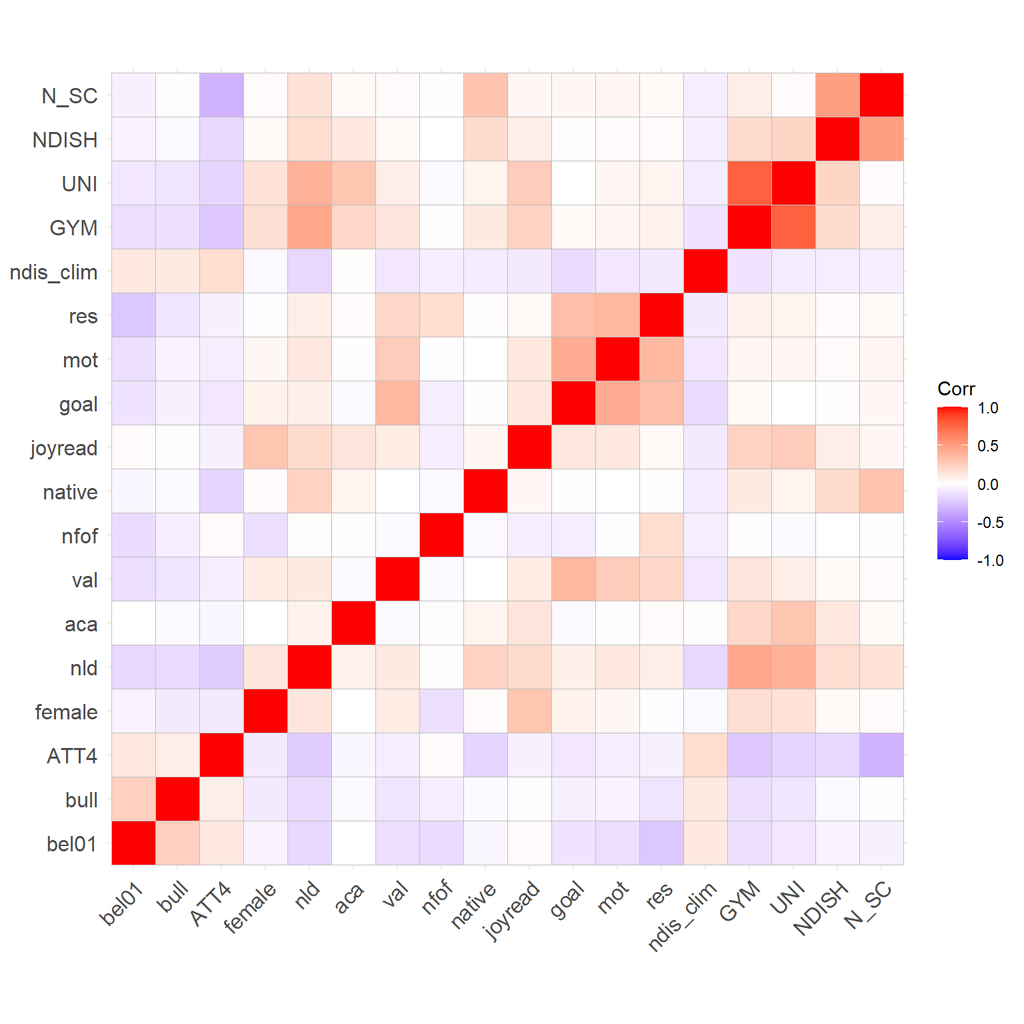

```r
cormat = pisa2018 %>%
    select(one_of(unlist(VARIABLES))) %>%
    mutate(across(where(is.factor), as.numeric)) %>%
    cor(use = "pairwise.complete.obs", method = "spearman")

ggcorrplot::ggcorrplot(cormat)
```

Focal predictors - important for target estimands.

```r
tbl_cross(pisa2018, bull, ATT4)
```

|  | ATT4 [0,0.114] | ATT4 (0.114,0.176] | ATT4 (0.176,0.25] | ATT4 (0.25,0.6] | Total |  |
| --- | --- | --- | --- | --- | --- | --- |
| bull |  |  |  |  |  |  |
| 0 | 1,572 | 1,492 | 1,425 | 1,306 | 5,795 |  |
| 1 | 131 | 147 | 191 | 225 | 694 |  |
| Total | 1,703 | 1,639 | 1,616 | 1,531 | 6,489 |  |

# 5 Sessioninfo

To build this notebook:

- install `quarto`
- make sure the data is in the correct folder (either in global Data folder, or as subfolder of the folder containing this notebook).
- build using the `make.R` script (global Data), or using the Render button in RStudio (subfolder Data).

```r
params
```

```
$folder_analysis
[1] "Data/Processed/School_FSAP"
```

```r
glue("Runtime {difftime(Sys.time(), T_START, units = 'm') / 60} hours.")
```

```
Runtime 0.00124497387144301 hours.
```